# Null bitdensity threshold: s(ll, k = 20) quantile regression + GPD tail (tau = 0.99)

## What this document does, and the assumptions it makes

Given a Foldseek search of random (“null”) proteins against the target structure DB, this notebook builds an **alignment-length-keyed background threshold** for `bitdensity = bits / (qend - qstart + 1)`, plus a GPD tail on its exceedances. The steps, in order:

1. **Reduce the null with a binomial identity test (Bonferroni, alpha = 0.05).** A handful of “null” queries are actually detectable homologs. We flag them with a per-alignment binomial test on the number of identical residues and drop the significant ones, so the surviving set is a clean chance background.
2. **Fit the threshold** `bitdensity ~ s(ll, k = 20)` (`ll = log alignment length`) by ALD (asymmetric-Laplace) quantile regression and check its exceedance calibration across alignment length.
3. **Sweep the quantile `tau`** for that threshold and check GPD tail-parameter stability across threshold choices.
4. **At `tau = 0.99`**, take the excesses and compare a constant vs. an `s(ll)`-varying GPD scale with the **probability integral transform (PIT)** QQ plot; the constant scale is adopted.
5. **Export the model** to `random_protein_null/exports_gam_bin_evt` — a per-`aln_len` lookup of the threshold `u` and GPD `sigma`, the constant GPD tail parameters, and the null samples.

**Assumptions introduced here (not part of the raw data):**

- *Binomial identity model.* Identical residues along an alignment are treated as i.i.d. `Bernoulli(q(L))`, so the identical-residue count is `Binomial(aln_len, q(L))`. This ignores positional correlation and is an approximation used only to *flag* obvious homologs.
- *Chance identity `q(L)`.* Estimated by a `qgam` median smooth `ident ~ s(log aln_len)` (the binned `a + b / sqrt(L)` curve and the Rost twilight-zone curve are drawn alongside for reference only, not used in the filter).
- *Threshold model.* `bitdensity ~ s(log aln_len, k = 20)`, ALD quantile regression with `evgam`, at `tau = 0.99` for the operative export.
- *GPD tail.* Excesses over the threshold follow a Generalised Pareto with a **constant scale** and **constant shape** (log link). An `s(log aln_len)`-varying scale is compared in step 4 and the constant scale is adopted on the PIT-exponential QQ evidence.
- *Extrapolation for the export lookup.* For `aln_len` below the smallest observed value, the smooth is evaluated at the boundary (`ll` clamped to `log(min observed aln_len)`) and the row is flagged `extrapolated = TRUE`.
- `bitdensity` is only defined where an alignment exists, so no-hit rows are dropped before any modelling.

```r
# Original best-hits with a 70% target-coverage filter applied to every hit (min tcov = 0.70).
# (The `best_hits_random_model_no_cov.tsv` variant has no coverage filter.)
null_model_file <- "C:/Masters_data/Master_thesis/foldseek_search/null_model_quantile_regression_files/random_proteins_best_hits.tsv"
fasta_file      <- "C:/Masters_data/Master_thesis/foldseek_search/random_protein_null/random_null_candidates.fasta"
mature_toxprot <-"C:/Masters_data/Master_thesis/foldseek_search/random_protein_null/Mature_sequences_toxprot.fasta"
max_length      <- 500
```

## Load the null-model Foldseek search

```r
null_model <- read_tsv(
  null_model_file,
  col_types = cols(
    query  = col_character(), target = col_character(),
    pident = col_double(),    alnlen = col_integer(),
    qstart = col_integer(),   qend   = col_integer(),
    tstart = col_integer(),   tend   = col_integer(),
    evalue = col_double(),    bits   = col_double()
  )
)
# One row per query confirms this is already "best hit per query by bitscore".
stopifnot(!any(duplicated(null_model$query)))
null_model <- null_model[!is.na(null_model$bits), ]
```

## Histogram of the null-model bitscore distribution

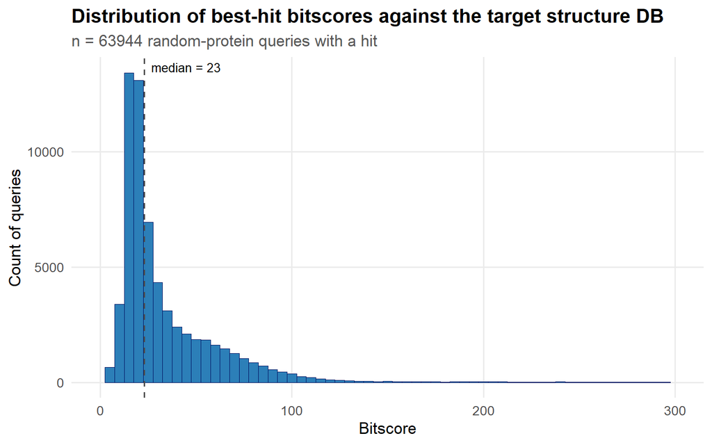

```r
med_bits <- median(null_model$bits)

ggplot(null_model, aes(x = bits)) +
  geom_histogram(binwidth = 5, fill = "#2c7fb8", color = "#000e5e", linewidth = 0.2) +
  geom_vline(xintercept = med_bits, linetype = "dashed", color = "grey30") +
  annotate("text", x = med_bits, y = Inf, label = paste0("median = ", round(med_bits, 1)),
           hjust = -0.1, vjust = 1.5, size = 3.5) +
  labs(title = "Distribution of best-hit bitscores against the target structure DB",
       subtitle = paste0("n = ", nrow(null_model), " random-protein queries with a hit"),
       x = "Bitscore", y = "Count of queries") +
  xlim(0, 300) +
  plot_theme
```

## Query lengths from the FASTA

Length is read directly from `random_null_candidates.fasta`. Headers look like `>ACCESSION length_bin=... organism="..."`; `parse_fasta_lengths()` takes the first whitespace-delimited token as the id, so the extra description text is ignored.

```r
parse_fasta_lengths <- function(path) {
  lines <- readLines(path)
  header_idx <- which(startsWith(lines, ">"))
  ids <- sub("^>(\\S+).*", "\\1", lines[header_idx])
  starts <- header_idx + 1L
  ends   <- c(header_idx[-1] - 1L, length(lines))
  seq_lengths <- mapply(function(s, e) if (s > e) 0L else sum(nchar(lines[s:e])), starts, ends)
  tibble(query = ids, length = as.integer(seq_lengths))
}

fasta_lengths <- parse_fasta_lengths(fasta_file)
fasta_lengths_toxprot <-parse_fasta_lengths(mature_toxprot)
n_dup <- sum(duplicated(fasta_lengths$query))
if (n_dup > 0) {
  message(n_dup, " duplicate FASTA headers found; keeping the first occurrence of each")
  fasta_lengths <- fasta_lengths %>% distinct(query, .keep_all = TRUE)
}
cat("Candidate queries in the FASTA:", nrow(fasta_lengths), "\n")
```

```
## Candidate queries in the FASTA: 64468
```

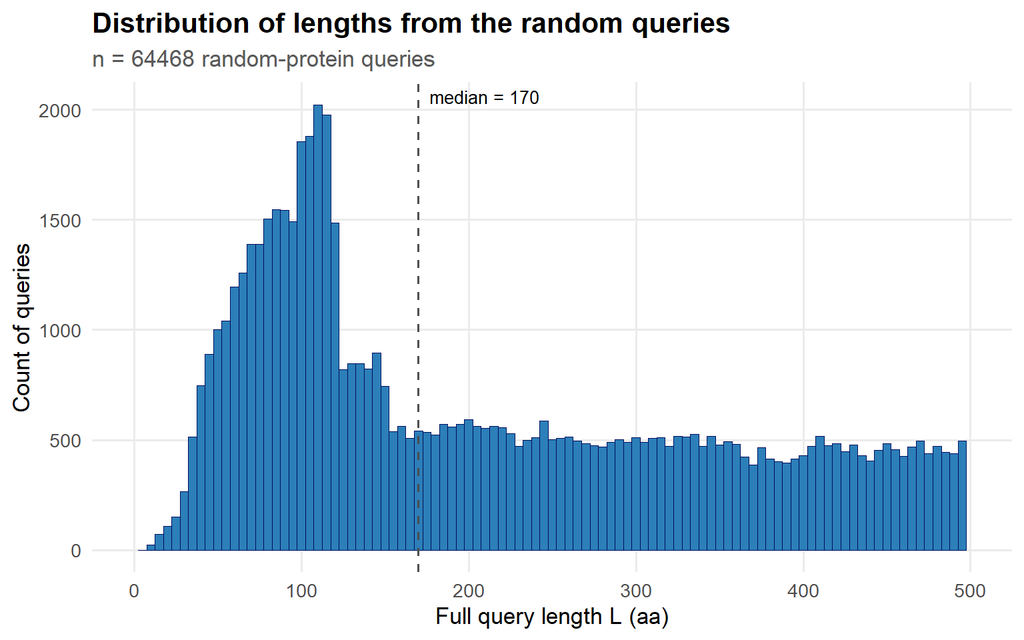

```r
med_lengths <- median(fasta_lengths$length)

ggplot(fasta_lengths, aes(x = length)) +
  geom_histogram(binwidth = 5, fill = "#2c7fb8", color = "#000e5e", linewidth = 0.2) +
  geom_vline(xintercept = med_lengths, linetype = "dashed", color = "grey30") +
  annotate("text", x = med_lengths, y = Inf, label = paste0("median = ", round(med_lengths, 1)),
           hjust = -0.1, vjust = 1.5, size = 3.5) +
  labs(title = "Distribution of lengths from the random queries",
       subtitle = paste0("n = ", nrow(fasta_lengths), " random-protein queries"),
       x = "Full query length L (aa)", y = "Count of queries") +
  xlim(0, 500) +
  plot_theme
```

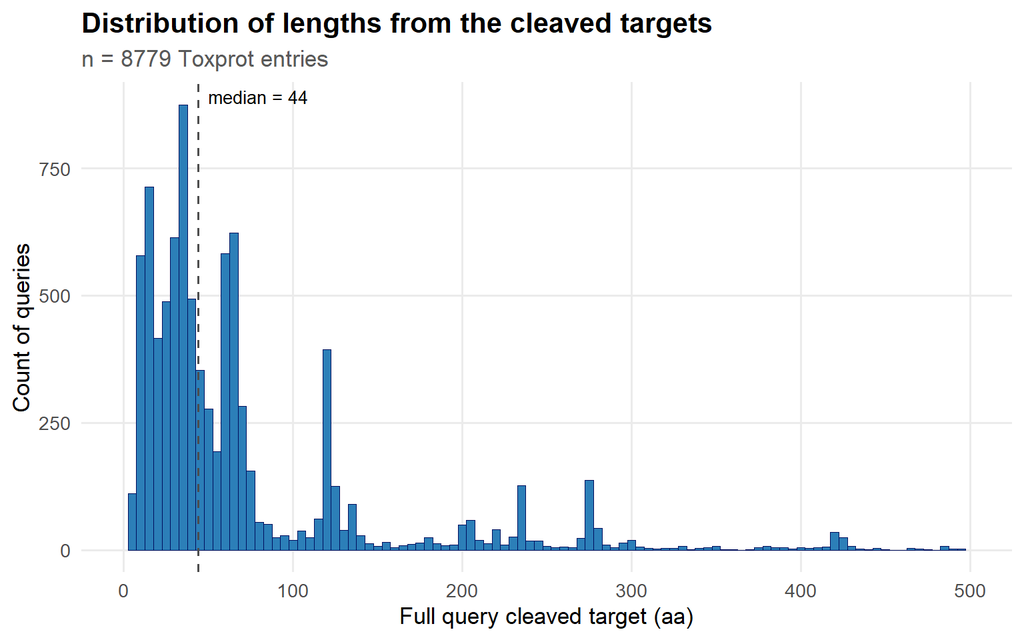

```r
med_lengths <- median(fasta_lengths_toxprot$length)
ggplot(fasta_lengths_toxprot, aes(x = length)) +
  geom_histogram(binwidth = 5, fill = "#2c7fb8", color = "#000e5e", linewidth = 0.2) +
  geom_vline(xintercept = med_lengths, linetype = "dashed", color = "grey30") +
  annotate("text", x = med_lengths, y = Inf, label = paste0("median = ", round(med_lengths, 1)),
           hjust = -0.1, vjust = 1.5, size = 3.5) +
  labs(title = "Distribution of lengths from the cleaved targets",
       subtitle = paste0("n = ", nrow(fasta_lengths_toxprot), " Toxprot entries"),
       x = "Full query cleaved target (aa)", y = "Count of queries") +
  xlim(0, 500) +
  plot_theme
```

## Build the score table

For every candidate in the FASTA, look up its bitscore in the null-model table. If the query has no row there (no alignment survived Foldseek’s own filtering), the alignment is treated as bitscore 0 and `aln_len` (`= qend - qstart + 1`) is set to 0 rather than dropping the query.

```r
add_score_columns <- function(tbl) {
  tbl %>%
    left_join(null_model %>% select(query, target, qstart, qend, bits, evalue, pident,tend,tstart),
              by = "query") %>%
    mutate(
      in_null_table = !is.na(bits),
      bits          = ifelse(in_null_table, bits, 0),
      evalue        = pmax(evalue, 1e-75),
      aln_len       = ifelse(in_null_table, qend - qstart + 1, 0),
      bitdensity    = case_when(!in_null_table ~ 0,
                                aln_len > 0     ~ bits / aln_len,
                                TRUE            ~ NA_real_),
      ll = log(ifelse(in_null_table, qend - qstart + 1, 0)),  # log alignment length
      lm = log(length)  )                                # log full query length
    }

analysis_tbl <- fasta_lengths %>% add_score_columns()

cat("Candidate queries analysed:      ", nrow(analysis_tbl), "\n")
```

```
## Candidate queries analysed:       64468
```

```r
cat("  ...with a hit in null model:   ", sum(analysis_tbl$in_null_table), "\n")
```

```
##   ...with a hit in null model:    63944
```

```r
cat("  ...alignment set to 0 (no hit):", sum(!analysis_tbl$in_null_table), "\n")
```

```
##   ...alignment set to 0 (no hit): 524
```

```r
# bitdensity is only meaningful where an alignment exists: keep hits only.
hits <- analysis_tbl %>% drop_na()

print(nrow(hits))
```

```
## [1] 63944
```

```r
# target full length is joined for reference/diagnostics; the exported model uses only bitdensity.
hits<-hits |> left_join(fasta_lengths_toxprot |> rename(target = query, tfull_length = length),
    by = "target")
print(nrow(hits))
```

```
## [1] 63944
```

```r
head(hits, 10)
```

```
## # A tibble: 10 × 16
##    query      length target        qstart  qend  bits evalue pident  tend tstart
##    <chr>       <int> <chr>          <int> <int> <dbl>  <dbl>  <dbl> <int>  <int>
##  1 A0A0H3W5S2     12 Q8MTX2_PEPTI…      5    12     7   34.2   25      11      4
##  2 A0A6F9DJL2     11 C0HJK2_PEPTI…      4    10     6   37.1   42.8     8      2
##  3 A0A6F9DXA7     12 P0DMF1_PEPTI…      4    12    17   15.2   55.5    10      2
##  4 A0A8W4F8Y2     15 C0HJK2_PEPTI…      7    13     3   46.5   28.5     8      2
##  5 A2N8M3         12 B3EWG8_full        2    10     6   37.5   33.3    10      2
##  6 A2NU82         11 C5J886_PEPTI…      1    10     6   37.8   30      11      2
##  7 A2NUB3         14 A0A348G5W1_P…      2    14     6   37.0   53.8    17      5
##  8 C0HLK7         11 P86340_full        5    11    10   27.2   42.8     8      2
##  9 D2DT40         14 D2Y171_PEPTI…      3    12     8   31.7   30      13      4
## 10 D2DT43         15 F1CJ89_PEPTI…      9    15     5   39.8   42.8     9      3
## # ℹ 6 more variables: in_null_table <lgl>, aln_len <dbl>, bitdensity <dbl>,
## #   ll <dbl>, lm <dbl>, tfull_length <int>
```

# Step 1 — Reduce the null with a binomial identity test (Bonferroni, alpha = 0.05)

A few “null” queries are genuine homologs: they share more identical residues than chance allows. We estimate the length-dependent chance identity `q(L)`, then for each alignment compute the probability of seeing at least `n_ident = round(pident/100 * aln_len)` identities under `Binomial(aln_len, q(L))`, Bonferroni-correct across all alignments, and **drop** alignments whose adjusted p-value is `<= 0.05` (real homologs). The rest stay in the null.

```r
hits <- hits %>% mutate(n_ident = round(pident / 100 * aln_len),
                      ll=log(aln_len),
                      ident_hundred=pident/100)

# Binned background identity, then q(L) = a + b / sqrt(L)
# --- add dispersion diagnostics to qtab --------------------------------
qtab <- hits %>%
  mutate(bin = cut(aln_len, c(0, 20, 40, 60, 80, 120, 160, 250, 500))) %>%
  group_by(bin) %>%
  summarise(n       = n(),
            L       = median(aln_len, na.rm = TRUE),
            q_med   = median(pident, na.rm = TRUE) / 100,
            q_mle   = sum(n_ident, na.rm = TRUE) / sum(aln_len, na.rm = TRUE),
            sd_emp  = sd(ident_hundred, na.rm = TRUE),
            mad_raw = mad(ident_hundred, constant = 1, na.rm = TRUE),  # unscaled
            mad_sc  = mad(ident_hundred, na.rm = TRUE),                # 1.4826 (R default)
            .groups = "drop") %>%
  mutate(sd_binom  = sqrt(q_med * (1 - q_med) / L),
         ratio_sd  = sd_emp / sd_binom,
         ratio_mad = mad_sc / sd_binom,
         lab       = sprintf("MAD %.3f (%.2f\u00d7)\nSD %.3f (%.2f\u00d7)",
                             mad_sc, ratio_mad, sd_emp, ratio_sd))

qfit    <- nls(q_med ~ a + b / sqrt(L), data = qtab, start = list(a = 0.09, b = 0.7))

# The qgam identity smooth is the slowest fit in the notebook; cache it to disk so re-runs
# load it instead of refitting. Delete cache/med_fit.rds (or the whole cache/ dir) to refresh.
cache_dir <- "C:/Masters_data/Master_thesis/foldseek_search/random_protein_null/cache"
dir.create(cache_dir, showWarnings = FALSE, recursive = TRUE)
med_cache <- file.path(cache_dir, "med_fit.rds")
if (file.exists(med_cache)) {
  med_fit <- readRDS(med_cache)
} else {
  med_fit <- qgam(ident_hundred ~ s(ll), data = hits, qu = 0.50)
  saveRDS(med_fit, med_cache)
}

print(qtab %>% select(bin, n, L, q_med, sd_binom, sd_emp, mad_raw, mad_sc,
                      ratio_sd, ratio_mad), n = Inf)
```

```
## # A tibble: 8 × 10
##   bin           n     L q_med sd_binom sd_emp mad_raw mad_sc ratio_sd ratio_mad
##   <fct>     <int> <dbl> <dbl>    <dbl>  <dbl>   <dbl>  <dbl>    <dbl>     <dbl>
## 1 (0,20]     6878    17 0.307   0.112  0.0962  0.057  0.0845    0.860     0.755
## 2 (20,40]   17472    29 0.233   0.0785 0.0727  0.048  0.0712    0.926     0.907
## 3 (40,60]   10775    50 0.187   0.0551 0.0563  0.034  0.0504    1.02      0.914
## 4 (60,80]    5876    69 0.166   0.0448 0.0453  0.03   0.0445    1.01      0.993
## 5 (80,120]   6179    97 0.147   0.0360 0.0538  0.025  0.0371    1.50      1.03
## 6 (120,160]  4426   140 0.135   0.0289 0.0556  0.021  0.0311    1.92      1.08
## 7 (160,250]  7431   198 0.126   0.0236 0.0470  0.0160 0.0237    1.99      1.01
## 8 (250,500]  4907   305 0.121   0.0187 0.0537  0.0120 0.0178    2.87      0.953
```

```r
disp_tab <- function(df, label) {
  df %>%
    mutate(bin = cut(aln_len, c(0, 20, 40, 60, 80, 120, 160, 250, 500))) %>%
    group_by(bin) %>%
    summarise(n = n(), L = median(aln_len), q_med = median(pident)/100,
              sd_emp = sd(ident_hundred), mad_sc = mad(ident_hundred),
              .groups = "drop") %>%
    mutate(sd_binom  = sqrt(q_med * (1 - q_med) / L),
           ratio_sd  = sd_emp  / sd_binom,
           ratio_mad = mad_sc  / sd_binom,
           eps_mom   = pmax(0, sd_emp^2 - sd_binom^2) / (0.234^2),  # refit delta per bin
           set = label)
}
```

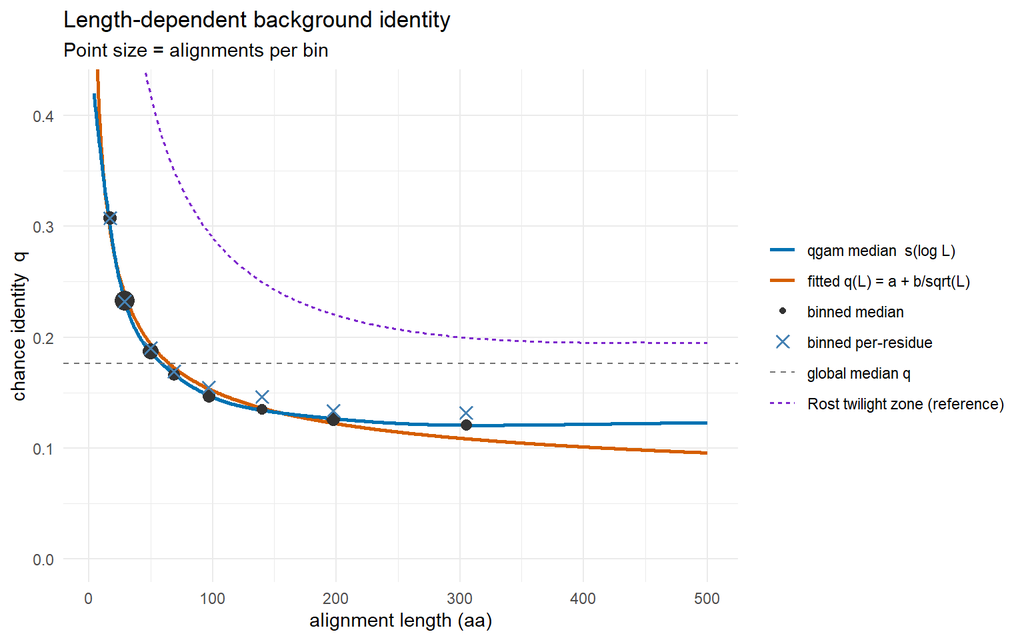

```r
q_global <- median(hits$pident, na.rm = TRUE) / 100

grid <- data.frame(aln_len = seq(4, 500, length.out = 600))
grid$q_fit <- predict(qfit, newdata = data.frame(L = grid$aln_len))
grid$q_qgam <- predict(med_fit, newdata = data.frame(ll = log(grid$aln_len)),type = "response")

# Rost twilight-zone curve, drawn for reference only (not used in the filter).
rost <- function(L) ifelse(L > 450, 19.5, 480 * L^(-0.32 * (1 + exp(-L / 1000)))) / 100

ggplot() +
  geom_line(data = grid, aes(aln_len, q_fit, colour = "fitted q(L) = a + b/sqrt(L)"),
            linewidth = 1) +
  geom_line(data = grid, aes(aln_len, q_qgam, colour = "qgam median  s(log L)"),
            linewidth = 1) +
  geom_point(data = qtab, aes(L, q_med, size = n, colour = "binned median")) +
  geom_point(data = qtab, aes(L, q_mle, colour = "binned per-residue"),
             shape = 4, size = 2.5, stroke = 1) +
  geom_line(data = grid, aes(aln_len, rost(aln_len), colour = "Rost twilight zone (reference)"),
            linetype = "22", linewidth = 0.7) +
  geom_hline(aes(yintercept = q_global, colour = "global median q"), linetype = "dashed") +
  scale_colour_manual(values = c("qgam median  s(log L)"          = "#0072B2",
               "fitted q(L) = a + b/sqrt(L)"    = "#D55E00",
               "binned median"                  = "grey20",
               "binned per-residue"             = "steelblue",
               "global median q"                = "grey45",
               "Rost twilight zone (reference)" = "purple3"),
    breaks = c("qgam median  s(log L)", "fitted q(L) = a + b/sqrt(L)",
               "binned median", "binned per-residue",
               "global median q", "Rost twilight zone (reference)"),
    name = NULL) +
  scale_size_area(max_size = 5, guide = "none") +
  coord_cartesian(ylim = c(0, 0.42)) +
  labs(x = "alignment length (aa)", y = "chance identity  q",
       title = "Length-dependent background identity",
       subtitle = "Point size = alignments per bin") +
  theme_minimal(base_size = 11)
```

```r
hits <- hits %>%
  mutate(q_L     = predict(med_fit, newdata = data.frame(ll = log(aln_len))),
         p_ident = pbinom(n_ident - 1, aln_len, q_L, lower.tail = FALSE),  # P(X >= n_ident)
         q_ident = p.adjust(p_ident, "bonferroni"),
         keep    = q_ident > 0.05 & !is.na(q_ident))

null_kept <- hits %>% filter(keep)

cat("Hits before filter:   ", nrow(hits), "\n")
```

```
## Hits before filter:    63944
```

```r
cat("Removed as homologs:  ", sum(!hits$keep), "\n")
```

```
## Removed as homologs:   681
```

```r
cat("Kept as null:         ", nrow(null_kept), "\n")
```

```
## Kept as null:          63263
```

```r
hits %>%
  mutate(bin = cut(aln_len, c(0, 40, 80, 160, 250, 500))) %>%
  group_by(bin) %>%
  summarise(
    n_alignments = n(),
    n_removed = sum(!keep),
    pct_removed = 100 * n_removed / n_alignments,
    .groups = "drop"
  )
```

```
## # A tibble: 5 × 4
##   bin       n_alignments n_removed pct_removed
##   <fct>            <int>     <int>       <dbl>
## 1 (0,40]           24350         3      0.0123
## 2 (40,80]          16651        23      0.138
## 3 (80,160]         10605       233      2.20
## 4 (160,250]         7431       207      2.79
## 5 (250,500]         4907       215      4.38
```

```r
print(bind_rows(
  disp_tab(hits, "pre-filter"),
  disp_tab(filter(hits, keep), "post-filter")
) %>%
  select(set, bin, n, ratio_sd, ratio_mad, eps_mom) %>%
  tidyr::pivot_wider(
    id_cols = bin,
    names_from = set,
    values_from = c(n, ratio_sd, ratio_mad, eps_mom)
  ),width=Inf)
```

```
## # A tibble: 8 × 9
##   bin       `n_pre-filter` `n_post-filter` `ratio_sd_pre-filter`
##   <fct>              <int>           <int>                 <dbl>
## 1 (0,20]              6878            6878                 0.860
## 2 (20,40]            17472           17469                 0.926
## 3 (40,60]            10775           10753                 1.02
## 4 (60,80]             5876            5875                 1.01
## 5 (80,120]            6179            6083                 1.50
## 6 (120,160]           4426            4289                 1.92
## 7 (160,250]           7431            7224                 1.99
## 8 (250,500]           4907            4692                 2.87
##   `ratio_sd_post-filter` `ratio_mad_pre-filter` `ratio_mad_post-filter`
##                    <dbl>                  <dbl>                   <dbl>
## 1                  0.860                  0.755                   0.755
## 2                  0.922                  0.907                   0.908
```

[output cut: 16 more lines]

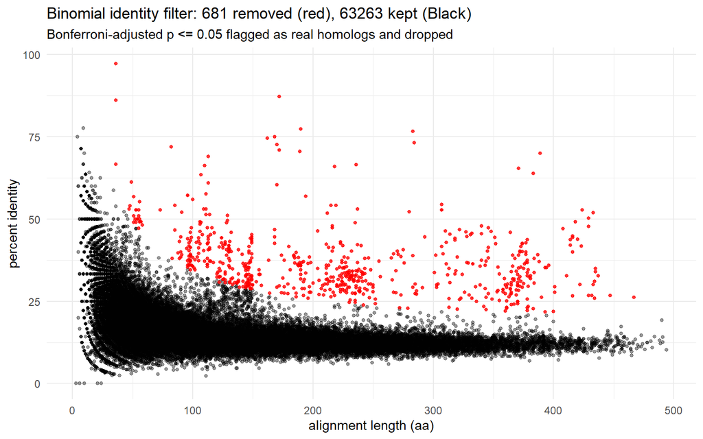

```r
ggplot(hits, aes(aln_len, pident)) +
  geom_point(data = subset(hits, keep),  colour = "#000000", size = 1, alpha = 0.4) +
  geom_point(data = subset(hits, !keep), colour = "red",    size = 1, alpha = 0.8) +
  labs(x = "alignment length (aa)", y = "percent identity",
       title = sprintf("Binomial identity filter: %d removed (red), %d kept (Black)",
                       sum(!hits$keep), sum(hits$keep)),
       subtitle = "Bonferroni-adjusted p <= 0.05 flagged as real homologs and dropped") +
  theme_minimal(base_size = 11)
```

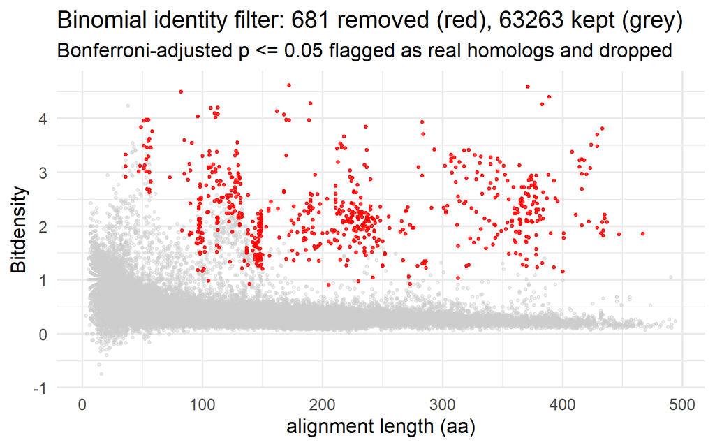

```r
ggplot(hits, aes(aln_len, bitdensity)) +
  geom_point(data = subset(hits, keep),  colour = "grey80", size = 1, alpha = 0.4) +
  geom_point(data = subset(hits, !keep), colour = "red",    size = 1, alpha = 0.8) +
  labs(x = "alignment length (aa)", y = "Bitdensity",
       title = sprintf("Binomial identity filter: %d removed (red), %d kept (grey)",
                       sum(!hits$keep), sum(hits$keep)),
       subtitle = "Bonferroni-adjusted p <= 0.05 flagged as real homologs and dropped") +
  theme_minimal(base_size = 16)
```

The reduced null used from here on (rows with a finite bitdensity):

```r
d <- null_kept %>% filter(is.finite(bitdensity), is.finite(ll))
cat("Modelling rows (reduced null): ", nrow(d), "\n")
```

```
## Modelling rows (reduced null):  63263
```

# Step 2 — Quantile-regression threshold: bitdensity ~ s(ll, k = 20)

The threshold for `bitdensity = bits / (qend - qstart + 1)` is a smooth of log alignment length, fit by ALD quantile regression at `tau = 0.99`. The calibration plot shows the realised exceedance rate (fraction of null hits above the fitted threshold) in equal-count bins of log alignment length; a well-calibrated threshold sits flat on the target `1 - tau`.

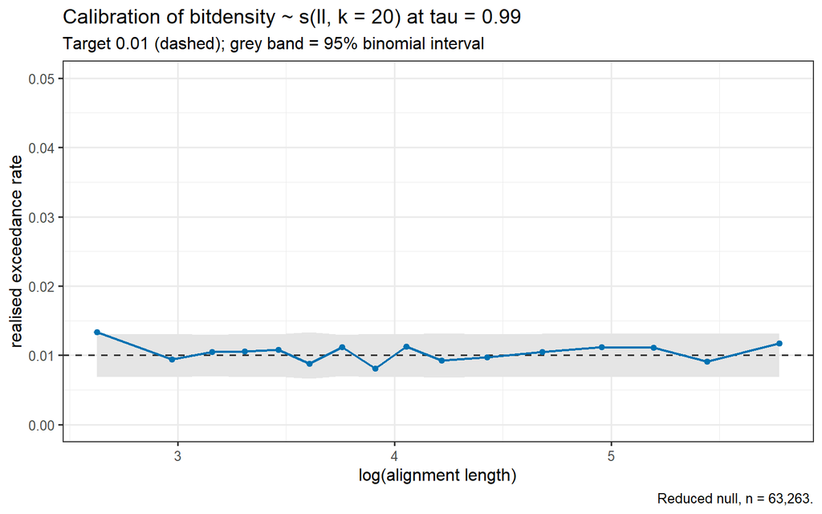

```r
tau <- 0.99
fit_calib <- evgam(bitdensity ~ s(ll, k = 20), data = d,
                   family = "ald", ald.args = list(tau = tau))
d$u_calib <- as.numeric(predict(fit_calib, newdata = d)$location)
d$hit     <- as.numeric(d$bitdensity > d$u_calib)

calib <- d %>%
  mutate(g = cut(ll, unique(quantile(ll, seq(0, 1, length.out = 17))), include.lowest = TRUE)) %>%
  group_by(g) %>%
  summarise(v = mean(hit), n = n(), ll = mean(ll), .groups = "drop") %>%
  filter(n >= 25) %>%
  mutate(se = sqrt((1 - tau) * tau / n),
         lo = pmax((1 - tau) - 1.96 * se, 0), hi = (1 - tau) + 1.96 * se)

ggplot(calib, aes(ll, v)) +
  geom_ribbon(aes(ymin = lo, ymax = hi), fill = "grey90") +
  geom_hline(yintercept = 1 - tau, linetype = 2, colour = "grey20") +
  geom_line(colour = "#0072B2", linewidth = 0.8) +
  geom_point(colour = "#0072B2", size = 1.5) +
  coord_cartesian(ylim = c(0, 0.05)) +
  labs(x = "log(alignment length)", y = "realised exceedance rate",
       title = "Calibration of bitdensity ~ s(ll, k = 20) at tau = 0.99",
       subtitle = paste0("Target ", 1 - tau, " (dashed); grey band = 95% binomial interval"),
       caption = sprintf("Reduced null, n = %s.", format(nrow(d), big.mark = ","))) +
  theme_bw(base_size = 12)
```

# Step 3 — Sweep tau for the s(ll, k = 20) threshold

Refit `bitdensity ~ s(ll, k = 20)` at several `tau`, fit a constant Generalised-Pareto tail to the excesses at each, and check that the GPD scale and shape are stable across threshold choices (a signature of a genuine GPD tail). The sweep (five ALD fits, each with a 200-sample GPD bootstrap) is cached to `cache/tau_sweep_bitdensity_k20.rds`; set `force_recompute_sweep <- TRUE` to refit.

```r
taus <- c(0.90, 0.95, 0.975, 0.99, 0.995)
tau_sweep_cache       <- file.path(cache_dir, "tau_sweep_bitdensity_k20.rds")
force_recompute_sweep <- FALSE

fit_at_tau <- function(dat, tau) {
  fu <- evgam(bitdensity ~ s(ll, k = 20), data = dat,
              family = "ald", ald.args = list(tau = tau))
  dat$u     <- as.numeric(predict(fu, newdata = dat)$location)
  ex        <- subset(dat, bitdensity > u)
  ex$excess <- ex$bitdensity - ex$u
  list(fit_u = fu, exc = ex, u = dat$u)
}

gpd_pars <- function(ex) {
  g  <- evgam(list(excess ~ 1, ~ 1), data = ex, family = "gpd")
  pr <- predict(g, newdata = ex[1, , drop = FALSE], type = "response")
  c(scale = as.numeric(pr$scale[1]), shape = as.numeric(pr$shape[1]))
}

boot_pars <- function(ex, B = 200) {
  out <- t(replicate(B, {
    bs <- ex[sample(nrow(ex), replace = TRUE), ]
    tryCatch(gpd_pars(bs), error = function(e) c(scale = NA, shape = NA))
  }))
  out[complete.cases(out), , drop = FALSE]
}

if (!force_recompute_sweep && file.exists(tau_sweep_cache)) {
  res <- readRDS(tau_sweep_cache)
} else {
  set.seed(1)
  res <- lapply(taus, function(tt) {
    message("sweep tau = ", tt)
    f  <- fit_at_tau(d, tt)
    pt <- gpd_pars(f$exc)
    bt <- boot_pars(f$exc, B = 200)
    data.frame(
      tau      = tt,
      n_exc    = nrow(f$exc),
      scale    = pt["scale"], shape = pt["shape"],
      scale_lo = quantile(bt[, "scale"], 0.025), scale_hi = quantile(bt[, "scale"], 0.975),
      shape_lo = quantile(bt[, "shape"], 0.025), shape_hi = quantile(bt[, "shape"], 0.975),
      u_mean   = mean(f$u)
    )
  }) %>% bind_rows()
  saveRDS(res, tau_sweep_cache)
}
res
```

```
##             tau n_exc     scale     shape  scale_lo  scale_hi   shape_lo
## scale...1 0.900  7169 0.1155195 0.5468497 0.1107776 0.1210734 0.51317275
## scale...2 0.950  3450 0.1617157 0.5506437 0.1509482 0.1757206 0.50323861
## scale...3 0.975  1702 0.2338170 0.3366965 0.2101086 0.2593564 0.26053000
## scale...4 0.990   662 0.3041894 0.1701441 0.2575415 0.3496180 0.07911097
## scale...5 0.995   331 0.2739467 0.1497143 0.2275452 0.3319708 0.02144014
##            shape_hi    u_mean
## scale...1 0.5793268 0.6958325
## scale...2 0.5872700 0.8124547
## scale...3 0.4062622 1.0048085
## scale...4 0.2772396 1.3341920
## scale...5 0.2907234 1.6241318
```

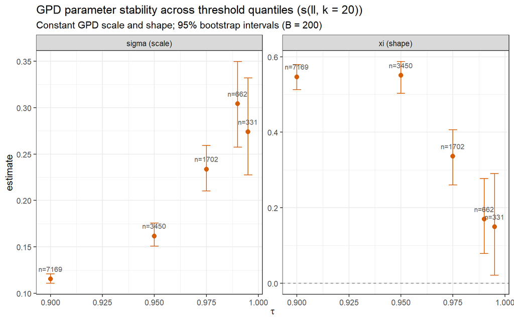

```r
res %>%
  tidyr::pivot_longer(c(scale, shape), names_to = "par", values_to = "est") %>%
  mutate(lo  = ifelse(par == "scale", scale_lo, shape_lo),
         hi  = ifelse(par == "scale", scale_hi, shape_hi),
         par = factor(par, c("scale", "shape"), c("sigma (scale)", "xi (shape)"))) %>%
  ggplot(aes(tau, est)) +
  geom_hline(data = data.frame(par = factor("xi (shape)", c("sigma (scale)", "xi (shape)"))),
             aes(yintercept = 0), linetype = 2, colour = "grey50") +
  geom_errorbar(aes(ymin = lo, ymax = hi), width = 0.004, colour = "#D55E00") +
  geom_point(size = 2.2, colour = "#D55E00") +
  geom_text(aes(label = paste0("n=", n_exc)), vjust = -1.4, size = 2.8, colour = "grey35") +
  facet_wrap(~ par, scales = "free_y") +
  labs(x = expression(tau), y = "estimate",
       title = "GPD parameter stability across threshold quantiles (s(ll, k = 20))",
       subtitle = "Constant GPD scale and shape; 95% bootstrap intervals (B = 200)") +
  theme_bw(base_size = 11)
```

# Step 4 — GPD estimation at the operative tau (s(ll, k = 20) threshold)

Fix the operative threshold quantile at `tau = 0.99`, fit `bitdensity ~ s(ll, k = 20)` there, take the excesses, and fit two GPD tails: a **constant scale** and a **scale varying as `s(ll)`** (both with constant shape). We judge them with the **probability integral transform**: under a correct GPD the transformed excess `w = (1/xi) * log(1 + xi * exc / sigma)` is standard exponential, so a QQ plot of `w` against `Exp(1)` quantiles should fall on the diagonal. The operative fit is cached to `cache/operative_bitdensity_k20.rds`.

```r
tau_export         <- 0.99
op_cache           <- file.path(cache_dir, "operative_bitdensity_k20.rds")
force_recompute_op <- FALSE

if (!force_recompute_op && file.exists(op_cache)) {
  op <- readRDS(op_cache)
} else {
  fit_u <- evgam(bitdensity ~ s(ll, k = 20), data = d,
                 family = "ald", ald.args = list(tau = tau_export))
  d$u   <- as.numeric(predict(fit_u, newdata = d)$location)
  d$exc <- d$bitdensity - d$u
  ex    <- filter(d, exc > 0)
  op <- list(fit_u = fit_u, ex = ex, zeta = mean(d$exc > 0), n_total = nrow(d),
             tau_export = tau_export,
             fit_g_const = evgam(list(exc ~ 1,     ~ 1), data = ex, family = "gpd"),
             fit_g_var   = evgam(list(exc ~ s(ll), ~ 1), data = ex, family = "gpd"))
  saveRDS(op, op_cache)
}

fit_u       <- op$fit_u;        ex         <- op$ex
zeta        <- op$zeta;         tau_export <- op$tau_export
fit_g_const <- op$fit_g_const;  fit_g_var  <- op$fit_g_var

# u / exc on every null row for the threshold curve and the export below.
d$u   <- as.numeric(predict(fit_u, newdata = d)$location)
d$exc <- d$bitdensity - d$u
c(n_exc = nrow(ex), p_exceed = zeta)
```

```
##        n_exc     p_exceed
## 662.00000000   0.01046425
```

```r
# PIT of a GPD excess to a standard exponential.
to_exp <- function(y, s, x) ifelse(abs(x) < 1e-6, y / s, log1p(x * y / s) / x)
pit <- bind_rows(
  {p <- predict(fit_g_const, newdata = ex, type = "response")
   tibble(w = to_exp(ex$exc, p$scale, p$shape), model = "constant scale")},
  {p <- predict(fit_g_var, newdata = ex, type = "response")
   tibble(w = to_exp(ex$exc, p$scale, p$shape), model = "scale ~ s(log l)")}
)
```

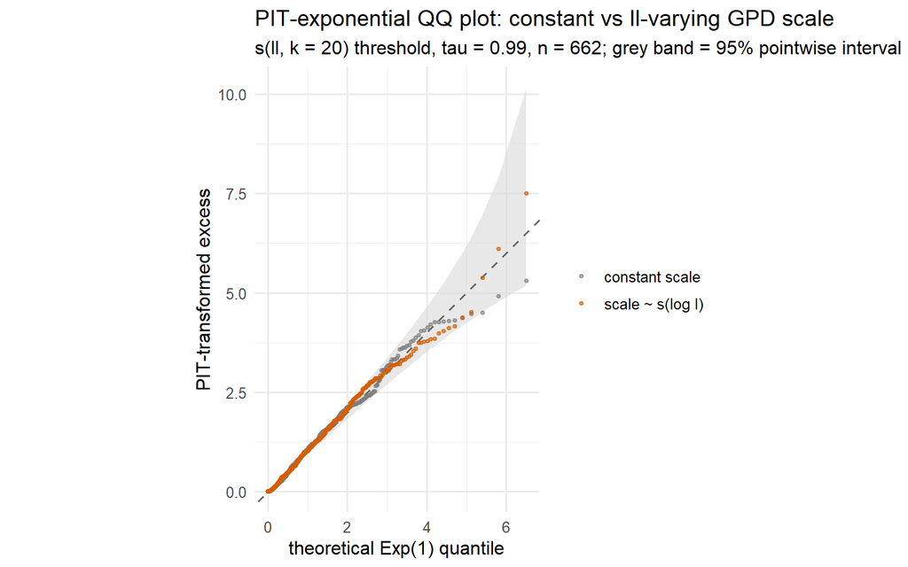

```r
pit_q <- pit %>%
  group_by(model) %>%
  arrange(w, .by_group = TRUE) %>%
  mutate(i    = row_number(),
         nn   = n(),
         theo = qexp(i / (nn + 1)),
         lo   = qexp(qbeta(0.025, i, nn - i + 1)),
         hi   = qexp(qbeta(0.975, i, nn - i + 1))) %>%
  ungroup()

band <- pit_q %>% filter(model == first(model))   # same n in both -> one ribbon

ggplot(pit_q, aes(theo, w)) +
  geom_ribbon(data = band, aes(x = theo, ymin = lo, ymax = hi),
              inherit.aes = FALSE, fill = "grey85", alpha = 0.6) +
  geom_abline(slope = 1, intercept = 0, linetype = 2, colour = "grey40") +
  geom_point(aes(colour = model), size = 0.8, alpha = 0.6) +
  scale_colour_manual(values = c("constant scale"   = "grey50",
                                 "scale ~ s(log l)" = "#D55E00"), name = NULL) +
  coord_equal() +
  labs(x = "theoretical Exp(1) quantile", y = "PIT-transformed excess",
       title = "PIT-exponential QQ plot: constant vs ll-varying GPD scale",
       subtitle = paste0("s(ll, k = 20) threshold, tau = ", tau_export, ", n = ", nrow(ex),
                         "; grey band = 95% pointwise interval under Exp(1)")) +
  theme_minimal(base_size = 12)
```

Both scales lie inside the 95% band, so they are hard to separate statistically (the two shapes agree to within ~1 SE). Given that, we adopt the simpler **constant-scale** GPD with constant shape. The histogram below overlays that fitted GPD density on the exceedances — it tracks them closely. Note only the *tail scale* is constant here; the threshold `u(ll)` itself stays length-dependent.

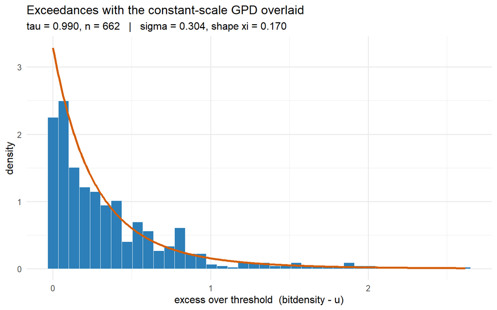

```r
# Constant-scale GPD: a single sigma and a single shape.
gp    <- predict(fit_g_const, newdata = ex[1, , drop = FALSE], type = "response")
sig_c <- as.numeric(gp$scale[1])
xi_c  <- as.numeric(gp$shape[1])

dgpd <- function(y, sigma, xi){
  if (abs(xi) < 1e-8)
    {dexp(y, rate = 1 / sigma)}
  else
    {ifelse(1 + xi * y / sigma > 0, (1 / sigma) * (1 + xi * y / sigma)^(-1 / xi - 1), 0)}
}
dens <- data.frame(exc = seq(0, max(ex$exc), length.out = 400))
dens$d <- dgpd(dens$exc, sig_c, xi_c)

ggplot(ex, aes(exc)) +
  geom_histogram(aes(y = after_stat(density)), bins = 40,
                 fill = "#2c7fb8", colour = "white", linewidth = 0.2) +
  geom_line(data = dens, aes(exc, d), colour = "#D55E00", linewidth = 1.1) +
  labs(x = "excess over threshold  (bitdensity - u)", y = "density",
       title = "Exceedances with the constant-scale GPD overlaid",
       subtitle = sprintf("tau = %.3f, n = %d   |   sigma = %.3f, shape xi = %.3f",
                          tau_export, nrow(ex), sig_c, xi_c)) +
  theme_minimal(base_size = 12)
```

The fitted threshold `u(aln_len)` across alignment length:

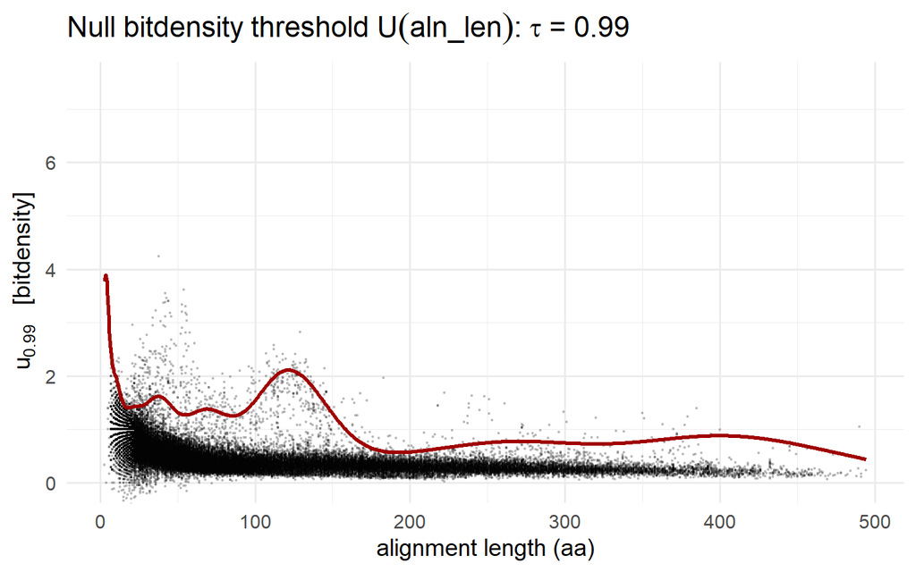

```r
aln_min <- min(d$aln_len); aln_max <- max(d$aln_len)

curve <- data.frame(aln_len = seq(aln_min, aln_max, length.out = 800))
curve$ll <- log(curve$aln_len)
curve$u  <- as.numeric(predict(fit_u, newdata = curve)$location)

ggplot() +
  geom_point(data = d, aes(aln_len, bitdensity), size = 0.3, alpha = 0.15) +
  geom_line(data = curve, aes(aln_len, u), colour = "#a00101", linewidth = 1.1) +
  coord_cartesian(ylim = c(0, 7.5)) +
  labs(x = "alignment length (aa)", y = expression(u[0.99] ~ "  [bitdensity]"),
       title = expression(paste("Null bitdensity threshold ", U(aln_len), ": ", tau, " = 0.99"))) +
  theme_minimal(base_size = 15)
```

# Step 5 — Export the model to `exports_gam_bin_evt`

Writes four files to `random_protein_null/exports_gam_bin_evt` (the other files already in that directory are left untouched):

- `u99_sigma_alnlen_lookup.csv` — per-`aln_len` threshold `u` (length-dependent) and GPD `sigma` (a single constant, repeated per row), with an `extrapolated` flag (TRUE below the smallest observed `aln_len`, where `ll` is clamped to the boundary).
- `gpd_tail_params.csv` — the constant GPD `scale` and `shape` (with the shape’s standard error), `p_exceed`, the counts, and the `aln_len` range.
- `null_bitdensity_sample.csv` — the reduced-null sample (`aln_len, length, bitdensity`).
- `null_excess_sample.csv` — the positive exceedances (`exc`).

```r
export_dir <- "C:/Masters_data/Master_thesis/random_protein_null/exports_gam_bin_evt"
dir.create(export_dir, showWarnings = FALSE, recursive = TRUE)

# --- constant-scale GPD: single shape (+ SE) and a single scale ----------------
shape_tab <- summary(fit_g_const)[[1]]$shape          # parametric-terms table for the shape
shape_hat <- shape_tab[1, "Estimate"]
se_shape  <- shape_tab[1, "Std. Error"]
scale_hat <- as.numeric(predict(fit_g_const, newdata = ex[1, , drop = FALSE],
                                type = "response")$scale[1])   # sigma is constant

# --- per-aln_len lookup; clamp ll at the boundary for aln_len below the minimum -
# u varies with alignment length; sigma is the single constant tail scale.
lut <- tibble(aln_len = seq_len(aln_max)) %>%
  mutate(ll = log(pmax(aln_len, aln_min)))
lut$u     <- as.numeric(predict(fit_u, newdata = lut)$location)   # evgam ALD -> $location
lut$sigma <- scale_hat                                            # constant
lut <- lut %>%
  mutate(extrapolated = aln_len < aln_min) %>%
  select(aln_len, u, sigma, extrapolated)

# --- tail parameter summary ---------------------------------------------------
gpd_tail_params <- tibble(
  threshold_tau = tau_export,
  p_exceed      = zeta,
  shape         = shape_hat,
  se_shape      = se_shape,
  scale         = scale_hat,          # single constant sigma (also filled per-row in the lookup)
  n_exceedances = nrow(ex),
  n_total       = op$n_total,
  aln_len_min   = aln_min,
  aln_len_max   = aln_max,
  u_formula     = "s(log(aln_len), k = 20), evgam ALD quantile regression (tau = 0.99)",
  sigma_formula = "constant (exc ~ 1), log link"
)

readr::write_csv(d %>% select(aln_len, length, bitdensity),
                 file.path(export_dir, "null_bitdensity_sample.csv"))
readr::write_csv(ex %>% select(exc),
                 file.path(export_dir, "null_excess_sample.csv"))
readr::write_csv(lut,
                 file.path(export_dir, "u99_sigma_alnlen_lookup.csv"))
readr::write_csv(gpd_tail_params,
                 file.path(export_dir, "gpd_tail_params.csv"))

gpd_tail_params
```

```
## # A tibble: 1 × 11
##   threshold_tau p_exceed shape se_shape scale n_exceedances n_total aln_len_min
##           <dbl>    <dbl> <dbl>    <dbl> <dbl>         <int>   <int>       <dbl>
## 1          0.99   0.0105 0.170   0.0536 0.304           662   63263           3
## # ℹ 3 more variables: aln_len_max <dbl>, u_formula <chr>, sigma_formula <chr>
```

```r
list.files(export_dir)
```

```
## [1] "gpd_tail_params.csv"
## [2] "null_bitdensity_sample.csv"
## [3] "null_excess_sample.csv"
## [4] "real_search_significance_results_FINAL.csv"
## [5] "real_search_significance_results_FINAL2.csv"
## [6] "u99_sigma_alnlen_lookup.csv"
```